# Ch. 18 - Linear Regression Models - Problem 18.1 Crime and Punishment

The data in linearRegression_crimePunishment.csv contains the murder rate per capita and the rate of automobile crimes per 100,000 individuals (both on the log scale) in the ten US States that have changed their legislation on capital punishment since 1960 (in all cases the states abolished capital punishment). We also include a dummy variable (“law”) that is 1 if the state allows capital punishment in that year, and 0 otherwise. The crime data is from http://www.disastercenter.com.

```r
cp_data <- readr::read_csv(here::here("STAN", "data",
                                      "linearRegression_crimePunishment.csv")) %>%
  select(-X1) %>% janitor::clean_names() %>%
  mutate(state_name = factor(state_name),
         state = as.integer(state),
         law = as.integer(law))
```

# Problem 18.1.1. Graph the data and comment on any trends.

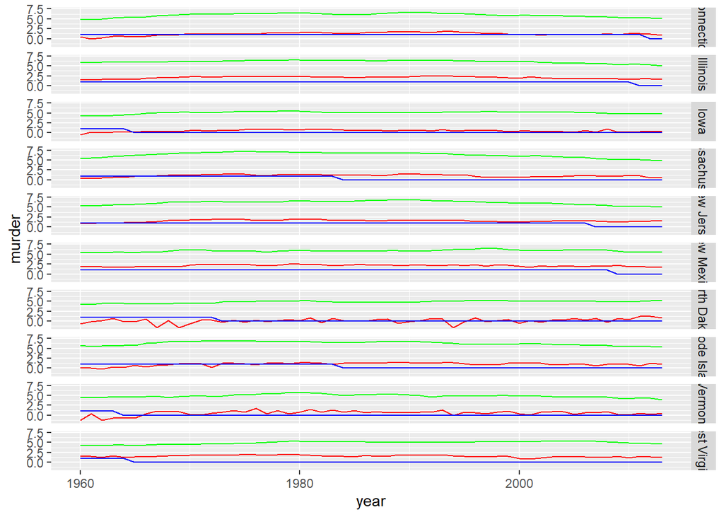

```r
library(ggplot2)

p <- ggplot(data = cp_data, aes(x = year)) +
  geom_line(aes(y = murder), color = "red") +
  geom_line(aes(y = car), color = "green") +
  geom_line(aes(y = law), color = "blue") +
  facet_grid(rows = vars(state_name))

p
```

There seems to be some association between the murder rate and auto crimes. In all cases it is difficult to visually discern an impact of the change in legislation.

# Problem 18.1.2.

A simple model for murder rates is of the form:

$$murder_{i,t} ∼ N(\alpha + \beta \times penalty_{i,t} + \gamma \times car_{i,t}, \sigma)$$
where we assume that the effect of having the death penalty is given by β, which is assumed to be the same across all states. We include $car_{i,t}$ – a measure of crimes on automobiles, as an independent variable to proxy for the contemporaneous underlying level of crime. Estimate this model and hence determine whether the death penalty acts as a deterrent to murder.

```r
library(rstan)
options(mc.cores = parallel:: detectCores())
rstan_options(auto_write = TRUE)

data_list <- list(N       = nrow(cp_data),
                  murder  = cp_data$murder,
                  penalty = cp_data$law,
                  car     = cp_data$car)

set.seed = 1

fit <- stan(here::here("STAN", "problem_18_1_linear_regression", "c_p.stan"),
            data = data_list,
            iter = 1000,
            chains = 4,
            warmup = 500)
```

```r
print(fit, c("alpha", "beta_car", "beta_penalty", "sigma", "lp__"))
```

```
## Inference for Stan model: c_p.
## 4 chains, each with iter=1000; warmup=500; thin=1;
## post-warmup draws per chain=500, total post-warmup draws=2000.
##
##                mean se_mean   sd   2.5%    25%    50%    75%  97.5% n_eff Rhat
## alpha         -1.47    0.01 0.23  -1.90  -1.64  -1.47  -1.31  -1.03   631 1.01
## beta_car       0.45    0.00 0.04   0.37   0.42   0.45   0.48   0.53   614 1.01
## beta_penalty   0.24    0.00 0.06   0.12   0.20   0.24   0.28   0.36   939 1.00
## sigma          0.62    0.00 0.02   0.59   0.61   0.62   0.64   0.66  1098 1.00
## lp__         -16.14    0.05 1.39 -19.58 -16.83 -15.83 -15.12 -14.37   876 1.00
##
## Samples were drawn using NUTS(diag_e) at Sun Oct 18 18:14:42 2020.
## For each parameter, n_eff is a crude measure of effective sample size,
## and Rhat is the potential scale reduction factor on split chains (at
## convergence, Rhat=1).
```

Where we see that we estimate that the imposition of the death penalty on average raises the murder rate by on average 24%!

# Problem 18.1.3.

An alternative model allows there to be state-level effects:

$$murder_{i,t} ∼ N(\alpha_i + \beta_i \times penalty_{i,t} + \gamma_i \times car_{i,t}, \sigma_i)$$

where we assume that $\alpha_i ∼ N(\bar{\alpha}, \sigma_\alpha)$, $\beta_i ∼ N(\bar{\beta}, \sigma_\beta)$ and $\gamma_i ∼ N(\bar{\gamma}, \sigma_\gamma)$ (we assume fully heterogeneous estimates for $\sigma$). Estimate the above model and compare the results with the homogeneous coefficient model.

```r
data_list <- list(K       = cp_data$state_name %>% unique %>% length,
                  N       = nrow(cp_data),
                  murder  = cp_data$murder,
                  penalty = cp_data$law,
                  car     = cp_data$car,
                  state   = cp_data$state)

set.seed = 1

fit_2 <- stan(here::here("STAN", "problem_18_1_linear_regression", "c_p_hyer.stan"),
              data = data_list,
              iter = 2000,
              chains = 4,
              warmup = 1000)
```

```r
print(fit_2, c("alpha", "beta_car", "beta_penalty", "sigma", "alpha_top",
             "sigma_alpha_top", "beta_car_top", "sigma_car_top",
             "beta_penalty_top", "sigma_penalty_top", "alpha_average",
             "beta_car_average", "beta_penalty_average", "lp__"))
```

```
## Inference for Stan model: c_p_hyer.
## 4 chains, each with iter=2000; warmup=1000; thin=1;
## post-warmup draws per chain=1000, total post-warmup draws=4000.
##
##                        mean se_mean   sd   2.5%    25%    50%    75%  97.5%
## alpha[1]              -2.17    0.01 0.38  -2.94  -2.43  -2.17  -1.92  -1.43
## alpha[2]              -1.63    0.01 0.37  -2.38  -1.87  -1.63  -1.38  -0.90
## alpha[3]              -1.85    0.01 0.46  -2.78  -2.15  -1.86  -1.56  -0.97
## alpha[4]              -1.35    0.01 0.27  -1.89  -1.53  -1.35  -1.17  -0.82
## alpha[5]              -1.13    0.01 0.30  -1.71  -1.34  -1.14  -0.94  -0.51
## alpha[6]              -0.59    0.01 0.55  -1.58  -0.97  -0.61  -0.25   0.57
## alpha[7]              -1.84    0.02 0.63  -3.05  -2.25  -1.86  -1.47  -0.54
## alpha[8]              -2.11    0.01 0.43  -2.97  -2.38  -2.10  -1.82  -1.28
## alpha[9]              -1.61    0.01 0.50  -2.66  -1.92  -1.61  -1.29  -0.60
## alpha[10]              0.23    0.03 0.75  -1.05  -0.33   0.19   0.74   1.79
## beta_car[1]            0.62    0.00 0.07   0.50   0.58   0.62   0.67   0.75
## beta_car[2]            0.65    0.00 0.07   0.51   0.60   0.65   0.69   0.79
## beta_car[3]            0.47    0.00 0.09   0.30   0.42   0.47   0.53   0.66
## beta_car[4]            0.40    0.00 0.04   0.31   0.37   0.39   0.42   0.48
## beta_car[5]            0.49    0.00 0.06   0.37   0.45   0.49   0.53   0.59
## beta_car[6]            0.46    0.00 0.10   0.25   0.40   0.46   0.53   0.63
## beta_car[7]            0.42    0.00 0.13   0.15   0.34   0.42   0.50   0.67
## beta_car[8]            0.53    0.00 0.07   0.40   0.49   0.53   0.58   0.67
## beta_car[9]            0.46    0.00 0.10   0.25   0.39   0.46   0.52   0.67
## beta_car[10]           0.27    0.01 0.15  -0.04   0.17   0.28   0.38   0.52
## beta_penalty[1]       -0.32    0.00 0.16  -0.63  -0.42  -0.31  -0.21  -0.01
## beta_penalty[2]       -0.23    0.00 0.11  -0.44  -0.30  -0.23  -0.16  -0.01
## beta_penalty[3]       -0.15    0.00 0.11  -0.37  -0.22  -0.15  -0.08   0.06
## beta_penalty[4]       -0.17    0.00 0.06  -0.28  -0.21  -0.16  -0.13  -0.05
## beta_penalty[5]       -0.35    0.00 0.09  -0.53  -0.41  -0.34  -0.29  -0.18
## beta_penalty[6]        0.05    0.00 0.12  -0.18  -0.02   0.05   0.13   0.29
## beta_penalty[7]       -0.22    0.00 0.16  -0.54  -0.33  -0.22  -0.12   0.10
## beta_penalty[8]       -0.46    0.00 0.08  -0.61  -0.51  -0.46  -0.41  -0.30
## beta_penalty[9]       -0.76    0.00 0.25  -1.26  -0.92  -0.75  -0.58  -0.29
## beta_penalty[10]       0.00    0.00 0.16  -0.29  -0.11   0.00   0.11   0.32
## sigma[1]               0.24    0.00 0.02   0.20   0.22   0.24   0.26   0.30
## sigma[2]               0.16    0.00 0.02   0.13   0.15   0.16   0.17   0.20
## sigma[3]               0.20    0.00 0.02   0.16   0.18   0.19   0.21   0.24
## sigma[4]               0.20    0.00 0.02   0.17   0.19   0.20   0.21   0.25
## sigma[5]               0.18    0.00 0.02   0.15   0.17   0.18   0.19   0.22
```

[output cut: 56 more lines]

```
## alpha_top             1761 1.00
## sigma_alpha_top       1048 1.01
## beta_car_top          2157 1.00
## sigma_car_top          898 1.01
## beta_penalty_top      2925 1.00
## sigma_penalty_top     2283 1.00
## alpha_average         4083 1.00
## beta_car_average      3574 1.00
## beta_penalty_average  3886 1.00
## lp__                  1055 1.00
##
## Samples were drawn using NUTS(diag_e) at Sun Oct 18 18:15:42 2020.
## For each parameter, n_eff is a crude measure of effective sample size,
## and Rhat is the potential scale reduction factor on split chains (at
## convergence, Rhat=1).
```

A mean effect size of a 25% reduction in murder rates although with a much wider range of effects.

# Problem extra. (Not in main text but wanted to include)

Another model allows there to be time trends in the data:

$$murder_{i,t} ∼ N(\alpha + \delta_i \times t + \beta \times penalty_{i,t} + \gamma \times car_{i,t}, \sigma)$$

where $δ_i ∼ N(\bar{\delta}, σ_\delta)$. Again estimate this model and compare the effect size of the death penalty across the three models.

```r
data_list <- list(K       = cp_data$state_name %>% unique %>% length,
                  N       = nrow(cp_data),
                  murder  = cp_data$murder,
                  penalty = cp_data$law,
                  car     = cp_data$car,
                  state   = cp_data$state,
                  t       = cp_data$year)

set.seed = 1

fit_3 <- stan(here::here("STAN", "problem_18_1_linear_regression", "c_p_hyer_2.stan"),
              data = data_list,
              # control = list(max_treedepth = 12),
              iter = 3000,
              chains = 4,
              warmup = 1000)
print(fit_3, c("alpha", "delta", "beta_car", "beta_penalty", "sigma",
               "alpha_top", "sigma_alpha_top",
               "delta_top", "sigma_delta_top",
               "beta_car_top", "sigma_car_top",
               "beta_penalty_top", "sigma_penalty_top",
               "alpha_average",
               "delta_average",
               "beta_car_average",
               "beta_penalty_average",
               "lp__"))
```

```
## Inference for Stan model: c_p_hyer_2.
## 4 chains, each with iter=3000; warmup=1000; thin=1;
## post-warmup draws per chain=2000, total post-warmup draws=8000.
##
##                        mean se_mean    sd   2.5%    25%    50%    75%  97.5%
## alpha[1]              -4.82    1.47  5.27 -18.84  -4.47  -2.57  -1.70  -0.49
## alpha[2]              -3.57    0.90  3.40 -12.50  -4.25  -2.27  -1.40  -0.03
## alpha[3]              -0.76    0.43  2.16  -4.03  -1.93  -1.13  -0.20   5.16
## alpha[4]              -2.81    0.74  3.14 -11.79  -3.02  -1.75  -1.08   0.18
## alpha[5]              -1.16    0.07  1.56  -4.31  -1.90  -1.16  -0.51   2.52
## alpha[6]              -0.07    0.46  2.32  -2.89  -1.29  -0.76   0.36   7.02
## alpha[7]              -1.91    0.32  2.09  -7.35  -2.70  -1.63  -0.78   1.48
## alpha[8]              -3.41    0.77  3.20 -12.93  -3.67  -2.19  -1.66  -0.24
## alpha[9]              -2.25    0.37  2.36  -9.01  -2.71  -1.71  -1.02   0.78
## alpha[10]              2.10    1.19  4.54  -1.99  -0.25   0.47   1.61  15.38
## delta[1]               0.00    0.00  0.00   0.00   0.00   0.00   0.00   0.01
## delta[2]               0.00    0.00  0.00   0.00   0.00   0.00   0.00   0.01
## delta[3]               0.00    0.00  0.00   0.00   0.00   0.00   0.00   0.00
## delta[4]               0.00    0.00  0.00   0.00   0.00   0.00   0.00   0.01
## delta[5]               0.00    0.00  0.00   0.00   0.00   0.00   0.00   0.00
## delta[6]               0.00    0.00  0.00   0.00   0.00   0.00   0.00   0.00
## delta[7]               0.00    0.00  0.00   0.00   0.00   0.00   0.00   0.00
## delta[8]               0.00    0.00  0.00   0.00   0.00   0.00   0.00   0.01
## delta[9]               0.00    0.00  0.00   0.00   0.00   0.00   0.00   0.00
## delta[10]              0.00    0.00  0.00  -0.01   0.00   0.00   0.00   0.00
## beta_car[1]            0.63    0.01  0.07   0.49   0.59   0.63   0.68   0.76
## beta_car[2]            0.67    0.01  0.08   0.52   0.62   0.67   0.72   0.82
## beta_car[3]            0.49    0.00  0.10   0.30   0.43   0.49   0.56   0.69
## beta_car[4]            0.39    0.00  0.04   0.31   0.36   0.39   0.42   0.48
## beta_car[5]            0.48    0.01  0.06   0.35   0.44   0.48   0.52   0.60
## beta_car[6]            0.45    0.01  0.11   0.22   0.38   0.45   0.52   0.64
## beta_car[7]            0.43    0.01  0.16   0.10   0.33   0.43   0.52   0.76
## beta_car[8]            0.55    0.01  0.08   0.40   0.50   0.55   0.60   0.70
## beta_car[9]            0.47    0.00  0.12   0.24   0.39   0.47   0.54   0.71
## beta_car[10]           0.20    0.01  0.15  -0.10   0.10   0.21   0.31   0.48
## beta_penalty[1]       -0.29    0.01  0.16  -0.61  -0.39  -0.28  -0.18   0.02
## beta_penalty[2]       -0.23    0.01  0.11  -0.44  -0.31  -0.23  -0.16  -0.02
## beta_penalty[3]       -0.15    0.00  0.11  -0.37  -0.22  -0.15  -0.08   0.07
## beta_penalty[4]       -0.15    0.01  0.07  -0.28  -0.19  -0.15  -0.10   0.00
## beta_penalty[5]       -0.33    0.01  0.10  -0.52  -0.40  -0.33  -0.27  -0.14
```

[output cut: 82 more lines]

```
## sigma_delta_top         14 1.32
## beta_car_top           421 1.01
## sigma_car_top          227 1.02
## beta_penalty_top       101 1.05
## sigma_penalty_top       99 1.05
## alpha_average         3626 1.00
## delta_average         2277 1.01
## beta_car_average      4101 1.00
## beta_penalty_average  2386 1.01
## lp__                    20 1.20
##
## Samples were drawn using NUTS(diag_e) at Sun Oct 18 18:25:58 2020.
## For each parameter, n_eff is a crude measure of effective sample size,
## and Rhat is the potential scale reduction factor on split chains (at
## convergence, Rhat=1).
```

```r
library(loo)
logLikelihood_homogeneous <- extract_log_lik(fit, "logLikelihood")
WAIC_homogeneous <- waic(logLikelihood_homogeneous)

logLikelihood_state_level_no_trend <- extract_log_lik(fit_2, "logLikelihood")
WAIC_state_level_no_trend <- waic(logLikelihood_state_level_no_trend)
logLikelihood_state_level_with_trend <- extract_log_lik(fit_3, "logLikelihood")
WAIC_state_level_with_trend <- waic(logLikelihood_state_level_with_trend)
compare(WAIC_homogeneous,
        WAIC_state_level_no_trend,
        WAIC_state_level_with_trend)
```

```
##                             elpd_diff se_diff elpd_waic p_waic waic
## WAIC_state_level_with_trend    0.0       0.0   -51.8      40.1  103.5
## WAIC_state_level_no_trend     -6.5       1.3   -58.3      35.3  116.5
## WAIC_homogeneous            -461.1      19.5  -512.9       4.7 1025.7
```

```r
loo_compare(WAIC_homogeneous,
        WAIC_state_level_no_trend,
        WAIC_state_level_with_trend)
```

```
##        elpd_diff se_diff
## model3    0.0       0.0
## model2   -6.5       1.3
## model1 -461.1      19.5
```

```r
LOO_homogeneous <- loo(logLikelihood_homogeneous)
LOO_state_level_no_trend <- loo(logLikelihood_state_level_no_trend)
LOO_state_level_with_trend <- loo(logLikelihood_state_level_with_trend)
compare(LOO_homogeneous,
        LOO_state_level_no_trend,
        LOO_state_level_with_trend)
```

```
##                            elpd_diff se_diff elpd_loo p_loo  looic
## LOO_state_level_with_trend    0.0       0.0   -52.7     41.0  105.3
## LOO_state_level_no_trend     -6.5       1.3   -59.1     36.1  118.3
## LOO_homogeneous            -460.2      19.6  -512.9      4.8 1025.7
```

```r
loo_compare(LOO_homogeneous,
            LOO_state_level_no_trend,
            LOO_state_level_with_trend)
```

```
##        elpd_diff se_diff
## model3    0.0       0.0
## model2   -6.5       1.3
## model1 -460.2      19.6
```

# Problem 18.1.5.

Critically evaluate the best-performing model and hence any conclusions that can be drawn from this analysis.

# Some plots

[Plotting MCMC draws using the bayesplot package](https://mc-stan.org/bayesplot/articles/plotting-mcmc-draws.html)

```r
library(bayesplot)
posterior <- as.array(fit)
dim(posterior)
```

```
## [1] 500   4 545
```

```r
# dimnames(posterior)
```

## Posterior uncertainty intervals

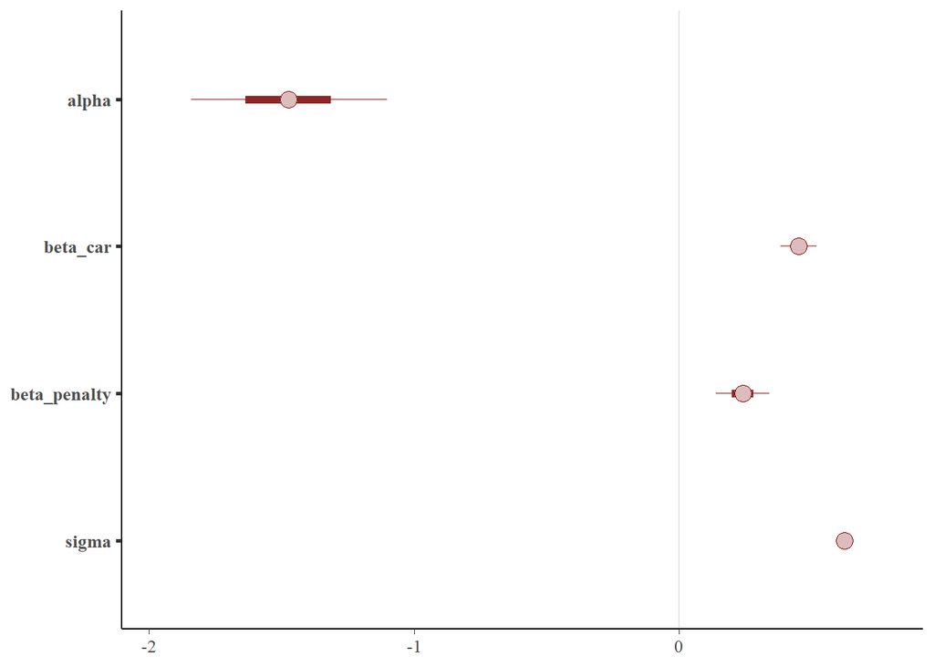

```r
color_scheme_set("red")
mcmc_intervals(posterior, pars = c("alpha","beta_car", "beta_penalty", "sigma"))
```

```r
mcmc_areas(
  posterior,
  pars = c("alpha","beta_car", "beta_penalty", "sigma"),
  prob = 0.8, # 80% intervals
  prob_outer = 0.99, # 99%
  point_est = "mean"
)
```

[figure not shown]

## Univariate marginal posterior distributions

```r
color_scheme_set("green")
mcmc_hist(posterior,
          pars = c(mcmc_areas(posterior,
                              pars = c("alpha", "beta_car", "beta_penalty", "sigma"),
                              prob = 0.8, # 80% intervals
                              prob_outer = 0.99, # 99%
                              point_est = "mean")))
```

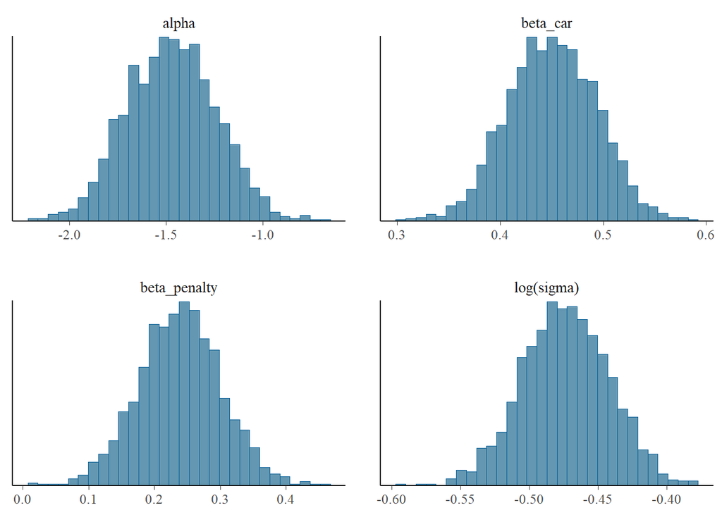

```r
color_scheme_set("blue")
mcmc_hist(posterior, pars = c("alpha", "beta_car", "beta_penalty", "sigma"),
          transformations = list("sigma" = "log"))
```

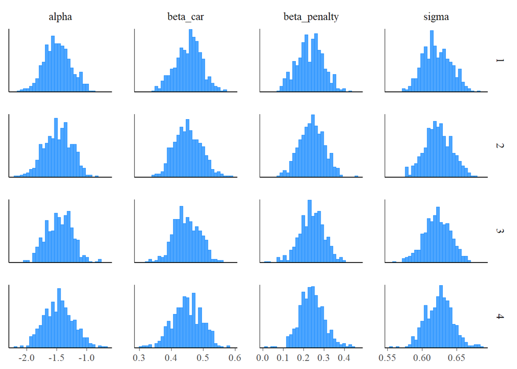

```r
color_scheme_set("brightblue")
mcmc_hist_by_chain(posterior, pars = c("alpha", "beta_car", "beta_penalty", "sigma"))
```

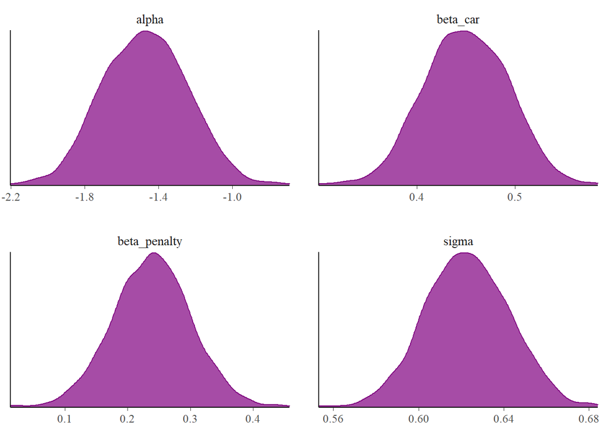

```r
color_scheme_set("purple")
mcmc_dens(posterior, pars = c("alpha", "beta_car", "beta_penalty", "sigma"))
```

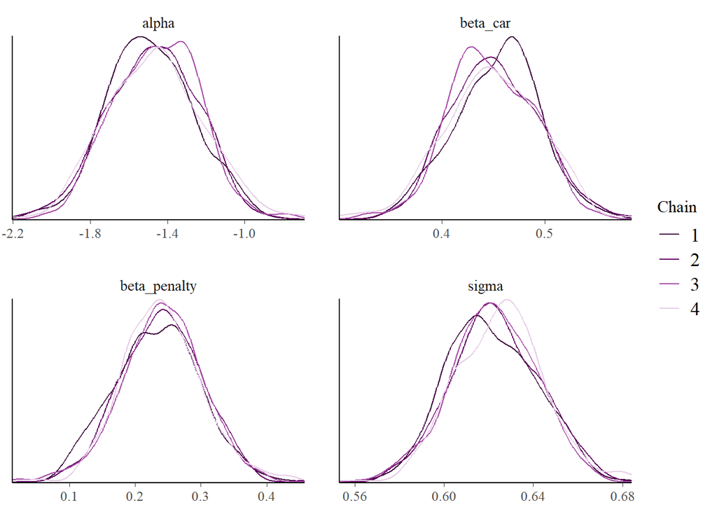

```r
mcmc_dens_overlay(posterior, pars = c("alpha", "beta_car", "beta_penalty", "sigma"))
```

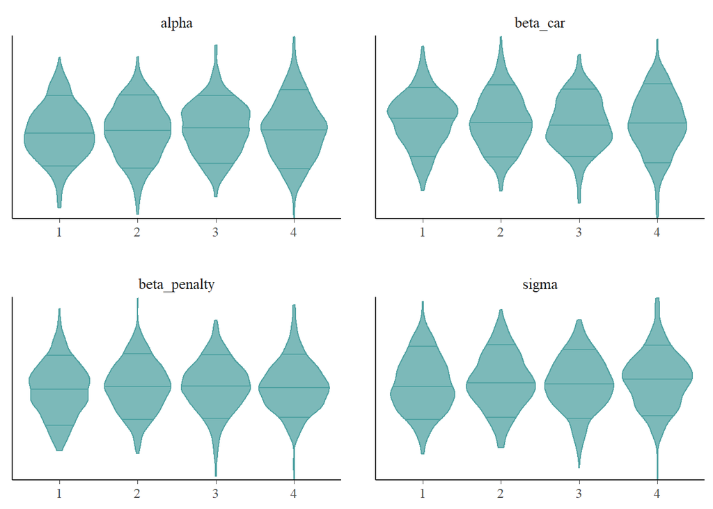

```r
color_scheme_set("teal")
mcmc_violin(posterior, pars = c("alpha", "beta_car", "beta_penalty", "sigma"), probs = c(0.1, 0.5, 0.9))
```

# Bivariate plots

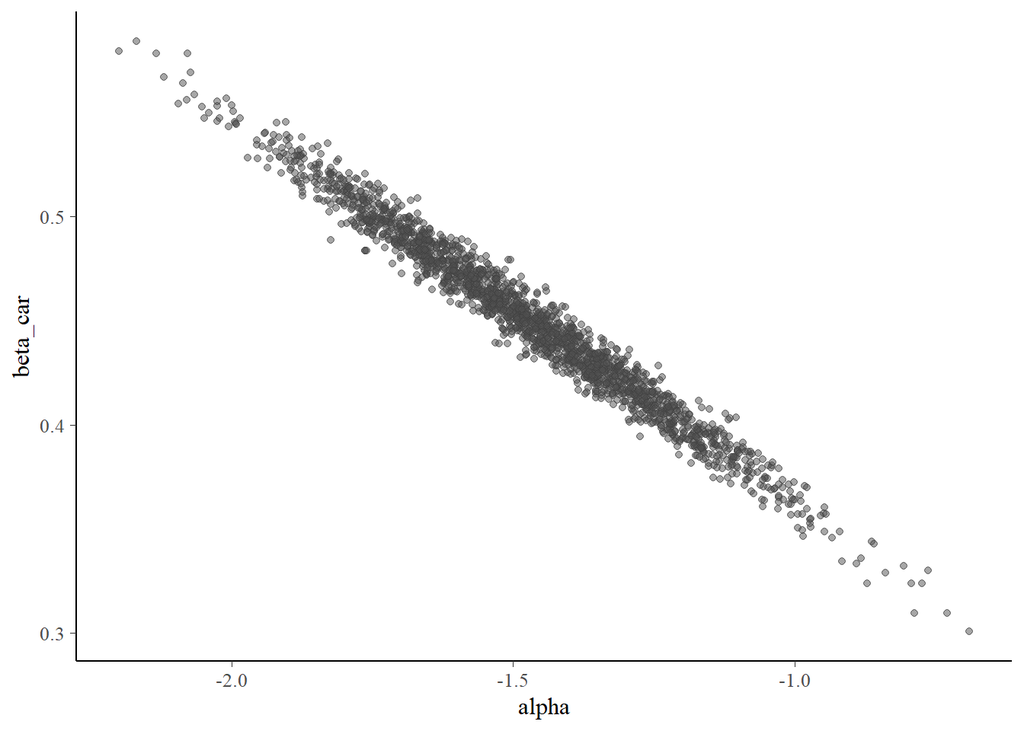

```r
color_scheme_set("gray")
mcmc_scatter(posterior, pars = c("alpha", "beta_car"),
             size = 1.5, alpha = 0.5)
```

```r
# requires hexbin package
if (requireNamespace("hexbin", quietly = TRUE)) {
  mcmc_hex(posterior, pars = c("alpha", "beta_car"))
}
```

[figure not shown]

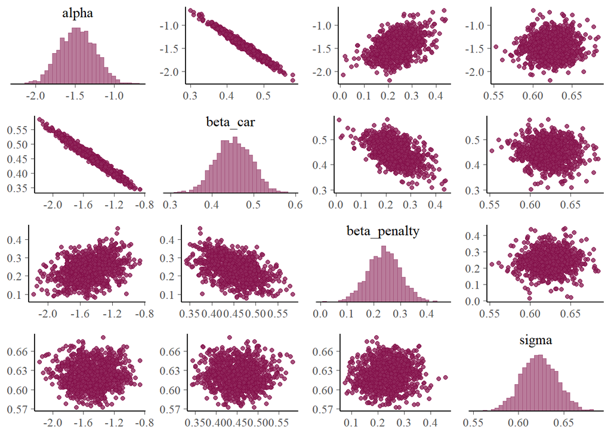

```r
color_scheme_set("pink")
mcmc_pairs(posterior, pars = c("alpha", "beta_car", "beta_penalty", "sigma"),
           off_diag_args = list(size = 1.5))
```